# Homework 7 and 8

Kunal Palawat

Preliminaries

```r
library(ggplot2)
```

Question 1

I expect to see extreme events, like hurricanes, in riparian zones resulting in increased leaching of nitrogen, carbon, and phosphorus from soil into water ways.

Question 2 Define sample size, means, sds. The means loosely come from my soil core leachate values for nitrate. I chose a very large sample size on purpose.

```r
sampleSize <- 100
meanTreatment1 <- 2
meanTreatment2 <- 6
sdTreatment1 <- 1
sdTreatment2 <- 2
```

Question 3

```r
# FUNCTION: createFakeData
# creates data frame with random normal values
# input: mean, n, and sd for 2 treatments
# output: data frame with 2 columns labeled ID and N_PPM
#---------

createFakeData <- function(mean1=2,mean2=6,
                       n1=100,n2=100,
                       sd1=1,sd2=2){

  ID <- c(rep("Treatment 1", n1), rep("Treatment 2", n2))

  treatment1 <- rnorm(mean=mean1,n=n1,sd=sd1)
  treatment2 <- rnorm(mean=mean2,n=n2,sd=sd2)

  myDF <- data.frame(ID, c(treatment1, treatment2))

  names(myDF) <- c("ID","N_PPM")
  return(myDF)
}
#---------

nitrogenPPMdf <- createFakeData()
```

Question 4 Function to analyze data

```r
# FUNCTION: anovaAnalysis
# ANOVA analysis for two treatments
# input: a data frame with two columns, N_PPM and ID
# output: summary of the ANOVA analysis: Sum Sq, Sum Mean Sq, F value, and p value
#--------
anovaAnalysis <- function(data = nitrogenPPMdf){
  model <- aov(N_PPM~ID, data = data)
  summary(model)
}
#--------

anovaAnalysis()
```

```
##              Df Sum Sq Mean Sq F value Pr(>F)
## ID            1  756.4   756.4   297.1 <2e-16 ***
## Residuals   198  504.1     2.5
## ---
## Signif. codes:  0 '***' 0.001 '**' 0.01 '*' 0.05 '.' 0.1 ' ' 1
```

Function to graph data

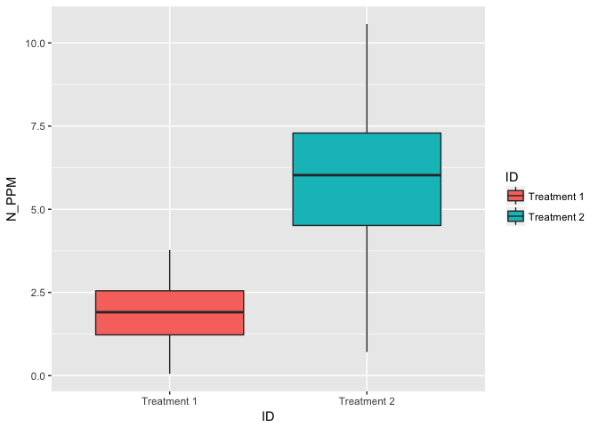

```r
# FUNCTION: anovaBoxplot
# creates boxplot of data to compare means
# input: a data frame with two columns, N_PPM and ID
# output: ggplot boxplot
#--------

anovaBoxplot <- function(data=nitrogenPPMdf){
ggplot(data=data,
       mapping = aes(x=ID, y=N_PPM, fill=ID)) +
    geom_boxplot()
}

anovaBoxplot()
```

Question 6 Analyze effect size.

```r
nitrogenPPMdf <- createFakeData(mean1 = 3.75)
anovaAnalysis()
```

```
##              Df Sum Sq Mean Sq F value Pr(>F)
## ID            1  315.7  315.65   124.3 <2e-16 ***
## Residuals   198  502.9    2.54
## ---
## Signif. codes:  0 '***' 0.001 '**' 0.01 '*' 0.05 '.' 0.1 ' ' 1
```

```r
nitrogenPPMdf <- createFakeData(mean1 = 6)
anovaAnalysis()
```

```
##              Df Sum Sq Mean Sq F value Pr(>F)
## ID            1      0  0.0203   0.008  0.927
## Residuals   198    480  2.4242
```

```r
nitrogenPPMdf <- createFakeData(mean1 = 1)
anovaAnalysis()
```

```
##              Df Sum Sq Mean Sq F value Pr(>F)
## ID            1   1206  1205.7   439.7 <2e-16 ***
## Residuals   198    543     2.7
## ---
## Signif. codes:  0 '***' 0.001 '**' 0.01 '*' 0.05 '.' 0.1 ' ' 1
```

```r
nitrogenPPMdf <- createFakeData(mean1 = 5.7)
anovaAnalysis()
```

```
##              Df Sum Sq Mean Sq F value   Pr(>F)
## ID            1   31.1  31.103   11.99 0.000657 ***
## Residuals   198  513.8   2.595
## ---
## Signif. codes:  0 '***' 0.001 '**' 0.01 '*' 0.05 '.' 0.1 ' ' 1
```

This model can detect very small differences in means but the sample size is HUGE! 100 is a large number. My actual study has a sample size of 15.

Question 7

So lets try decreasing the sample size to 15 and some other numbers and see what our results look like.

```r
nitrogenPPMdf <- createFakeData(n1 = 15,
                                n2 = 15)
anovaAnalysis()
```

```
##             Df Sum Sq Mean Sq F value   Pr(>F)
## ID           1  89.95   89.95   32.86 3.77e-06 ***
## Residuals   28  76.64    2.74
## ---
## Signif. codes:  0 '***' 0.001 '**' 0.01 '*' 0.05 '.' 0.1 ' ' 1
```

```r
nitrogenPPMdf <- createFakeData(n1 = 10,
                                n2 = 10)
anovaAnalysis()
```

```
##             Df Sum Sq Mean Sq F value  Pr(>F)
## ID           1  82.25   82.25   13.42 0.00178 **
## Residuals   18 110.30    6.13
## ---
## Signif. codes:  0 '***' 0.001 '**' 0.01 '*' 0.05 '.' 0.1 ' ' 1
```

```r
nitrogenPPMdf <- createFakeData(n1 = 3,
                                n2 = 3)
anovaAnalysis()
```

```
##             Df Sum Sq Mean Sq F value Pr(>F)
## ID           1  31.96   31.96   4.658 0.0971 .
## Residuals    4  27.44    6.86
## ---
## Signif. codes:  0 '***' 0.001 '**' 0.01 '*' 0.05 '.' 0.1 ' ' 1
```

```r
nitrogenPPMdf <- createFakeData(n1 = 2,
                                n2 = 2)
anovaAnalysis()
```

```
##             Df Sum Sq Mean Sq F value Pr(>F)
## ID           1  6.113   6.113   17.23 0.0534 .
## Residuals    2  0.710   0.355
## ---
## Signif. codes:  0 '***' 0.001 '**' 0.01 '*' 0.05 '.' 0.1 ' ' 1
```